# Lab_3_Yoo

Kwang il Yoo

10/22/2021

```r
library(sf)
library(tidyverse)
library(spdep)
library(tmap)
```

1. Create a spatial subset of the US, with at AT MINIMUM 4 states, MAXIMUM 7 states. States must be contiguous. Save this subset as a shapefile such that it’s sufficiently small in size that GitHub will accept the git-push

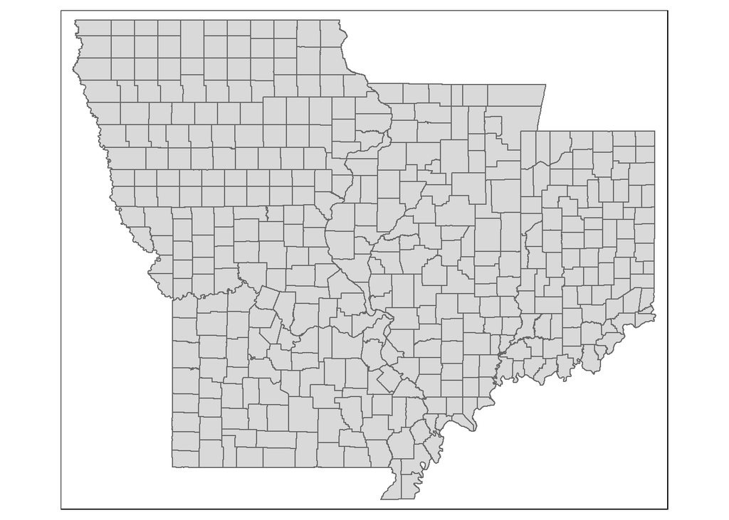

```r
d.all <- sf::read_sf("../data/County_2010Census_DP1.shp")
d.all <- d.all %>% mutate(ST = substr(GEOID10, 1, 2))
states <- dplyr::filter(d.all, ST == "17" | ST == "18" | ST == "19" | ST == "29")
tmap::tm_shape(states) + tm_polygons()
```

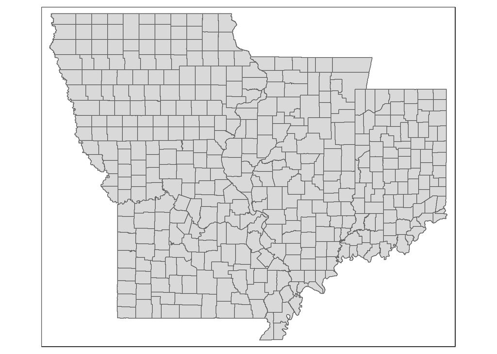

```r
##st_write(states, "../data/states_filter.shp")
states.all <- sf::read_sf("../data/states_filter.shp")
tmap::tm_shape(states.all) + tm_polygons()
```

2. Choose a variable. If it’s a raw count, you should normalize the variable in an appropriate manner (e.g., by total population, percent, by area)

```r
states.all <- states.all %>% mutate(pct_b = (DP0080004/DP0080001)*100)
```

3. Make a histogram of your chosen variable

```
## No summary function supplied, defaulting to `mean_se()`
```

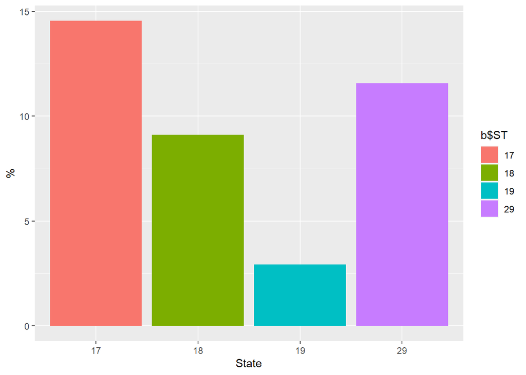

```r
b <- states.all %>%  as_tibble() %>% dplyr::select(-geometry) %>% group_by(ST) %>% summarise(percent_black = ((sum(DP0080004))/sum(DP0080001))*100)
ggplot(b) + geom_bar(aes(b$ST, b$percent_black, fill = b$ST), stat = "summary") + ylab("%") + xlab("State")
```

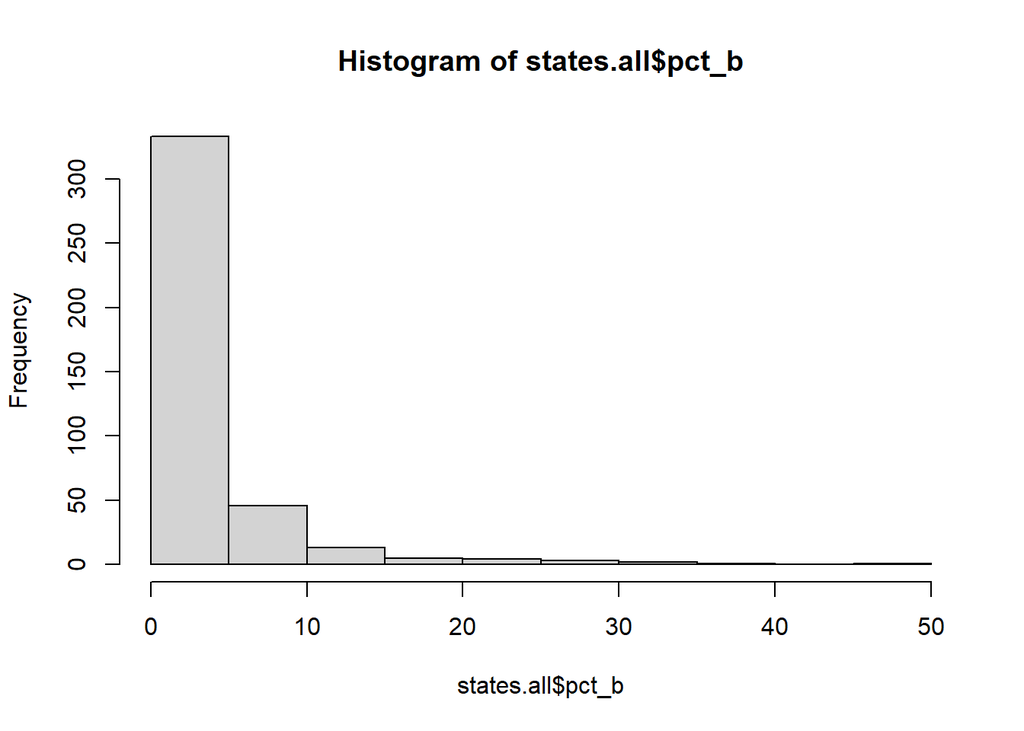

```r
hist(states.all$pct_b)
```

4. Make a choropleth map of your chosen variable. Choose an appropriate data classification scheme

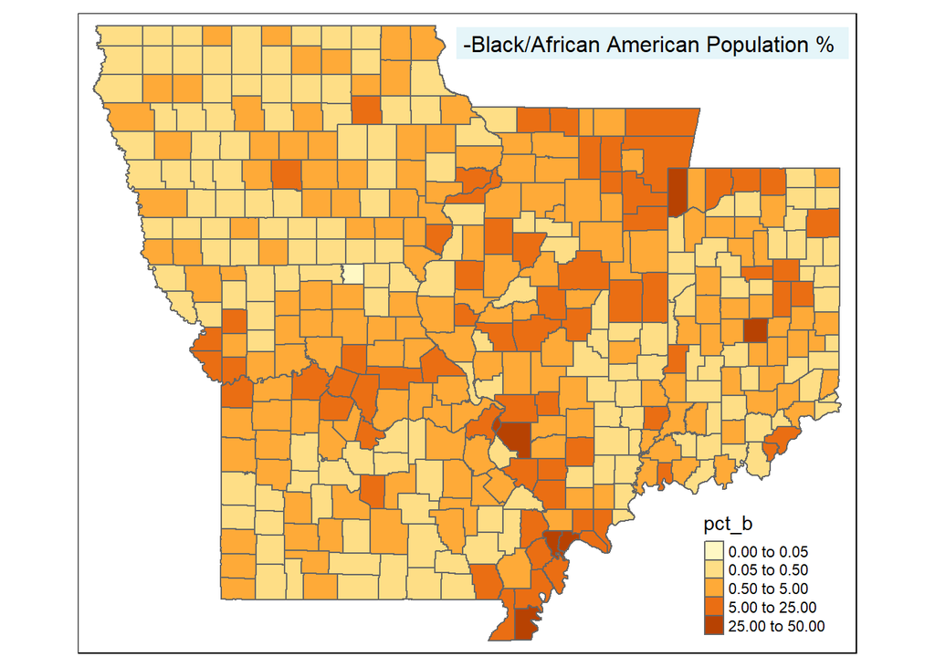

```r
tm_shape(states.all) +
  tm_polygons(col="pct_b", legend.show=T, breaks=c(0, 0.05, 0.5, 5, 25, 50)) +
  tm_layout(title= "-Black/African American Population %",
    title.position= c("right","top"), title.bg.color = "#e5f5f9", title.size = 1)
```

5. Develop a contiguity-based spatial weights matrix of your choosing (i.e., rook or queen)

```r
sf::st_crs(states.all)
```

```
## Coordinate Reference System:
##   User input: NAD83
##   wkt:
## GEOGCRS["NAD83",
##     DATUM["North American Datum 1983",
##         ELLIPSOID["GRS 1980",6378137,298.257222101,
##             LENGTHUNIT["metre",1]]],
##     PRIMEM["Greenwich",0,
##         ANGLEUNIT["degree",0.0174532925199433]],
##     CS[ellipsoidal,2],
##         AXIS["latitude",north,
##             ORDER[1],
##             ANGLEUNIT["degree",0.0174532925199433]],
##         AXIS["longitude",east,
##             ORDER[2],
##             ANGLEUNIT["degree",0.0174532925199433]],
##     ID["EPSG",4269]]
```

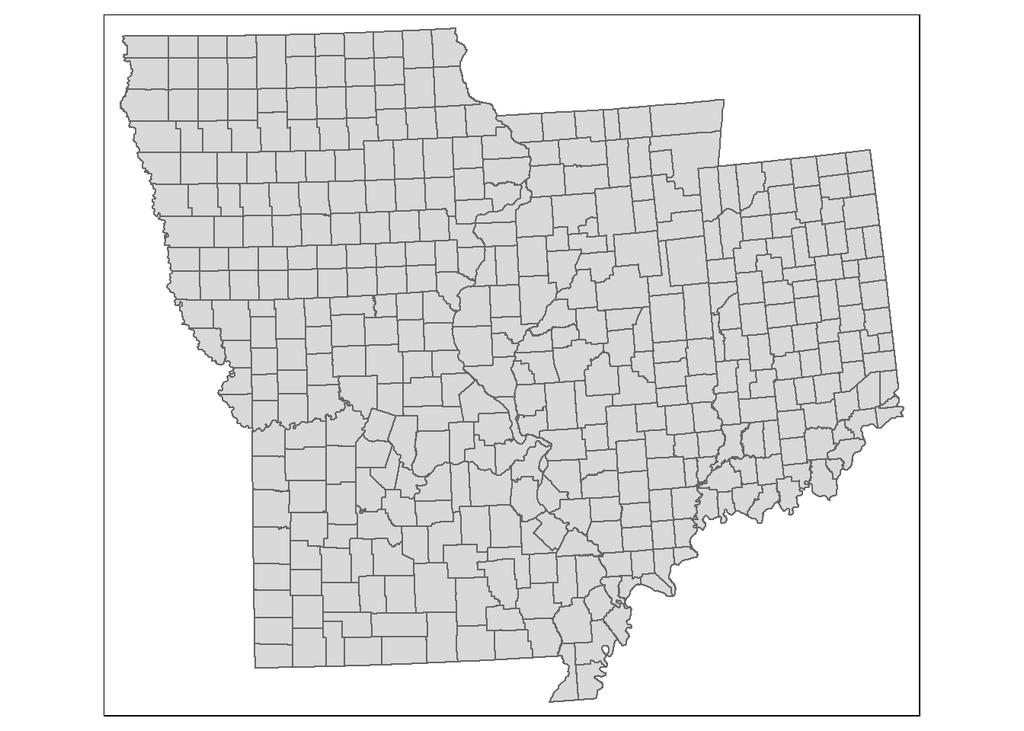

```r
states.proj <- states.all %>% sf::st_transform(., "ESRI:102010")
tmap::tm_shape(states.proj) + tm_polygons()
```

```r
states.q <- spdep::poly2nb(states.proj, queen = T)
states.q[[1]]
```

```
## [1]  20  28 109 143 300 380
```

```r
states.proj$NAMELSAD10[1]
```

```
## [1] "Jefferson County"
```

```r
states.q[[1]] %>% states.proj$NAMELSAD10[.]
```

```
## [1] "Monroe County"         "Franklin County"       "St. Francois County"
## [4] "St. Louis County"      "Ste. Genevieve County" "Washington County"
```

1. Row-standardize the W

```r
states.w <- nb2listw(states.q, style="W", zero.policy=TRUE)
states.w$weights[1]
```

```
## [[1]]
## [1] 0.1666667 0.1666667 0.1666667 0.1666667 0.1666667 0.1666667
```

2. Plot a histogram of the number of neighbors

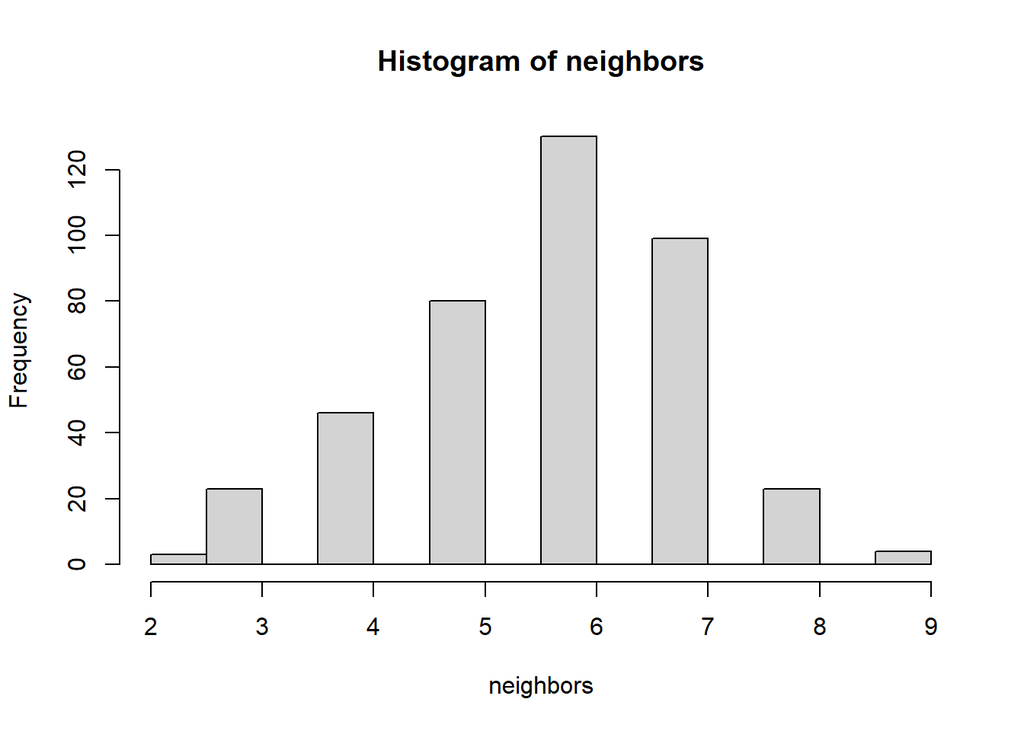

```r
neighbors <- attr(states.w$weights, "comp")$d
hist(neighbors)
```

```r
black.pct.lag <- lag.listw(states.w, states.proj$pct_b)
black.pct.lag
```

```
##   [1]  5.2474939  0.7269655 20.5629956  1.1871857  0.5422169  7.5409339
##   [7]  1.2913624  0.4914216  2.0980800  3.4819186  2.9233802  3.1803474
##  [13]  2.2541694  1.7664882  4.6579120  5.0268065 14.4678421  3.1644991
##  [19]  4.5572735 13.0045614  5.6992224  2.7563752  2.8334357  3.6149272
##  [25]  0.4393685  0.9396738 12.8941494  4.6955296  2.4477735  3.5110014
##  [31]  1.9978645  3.2934978  2.1561222  2.9050646  4.7544444  2.7835469
##  [37] 11.8545535  6.4205537  2.9366326 15.4594407  3.6439541  3.4088344
##  [43]  9.1672893  4.6936144  1.0895100  1.5705600  7.8722824  7.8613458
##  [49]  5.0160985  4.8708052 12.5288647  2.1241565  6.5289081  2.9603748
##  [55]  2.5037902  7.8694485  3.2297175  4.1943869  2.4342951  2.0480864
##  [61]  2.5446985  3.9177197  5.4180336  2.6401913  4.2928615 13.4571585
##  [67]  5.2558387  0.9576732  5.5395311  8.9224384  5.2602041  2.7191903
##  [73]  6.1833587  4.1958933 10.7394215  4.4486673  1.0670583  1.8975180
##  [79]  3.6007566  2.2944138  2.3185766  6.1423491  3.7466690  8.8232598
##  [85]  5.4883159  0.6577052  4.8487618  1.5175260  5.2149965  5.1726762
```

[output cut: 53 more lines]

4. Make a Moran Plot

```r
moran.test(states.proj$pct_b, states.w)
```

```
##
##  Moran I test under randomisation
##
## data:  states.proj$pct_b
## weights: states.w
##
## Moran I statistic standard deviate = 11.52, p-value < 2.2e-16
## alternative hypothesis: greater
## sample estimates:
## Moran I statistic       Expectation          Variance
##      0.3295051209     -0.0024570025      0.0008304095
```

```r
MC<- moran.mc(states.proj$pct_b, states.w, nsim=999)
MC
```

```
##
##  Monte-Carlo simulation of Moran I
##
## data:  states.proj$pct_b
## weights: states.w
## number of simulations + 1: 1000
##
## statistic = 0.32951, observed rank = 1000, p-value = 0.001
## alternative hypothesis: greater
```

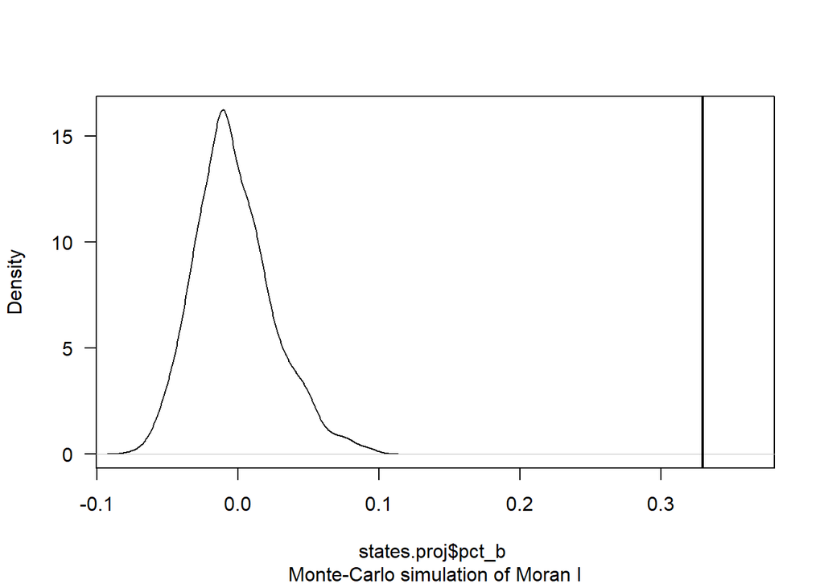

```r
plot(MC, main="", las=1)
```

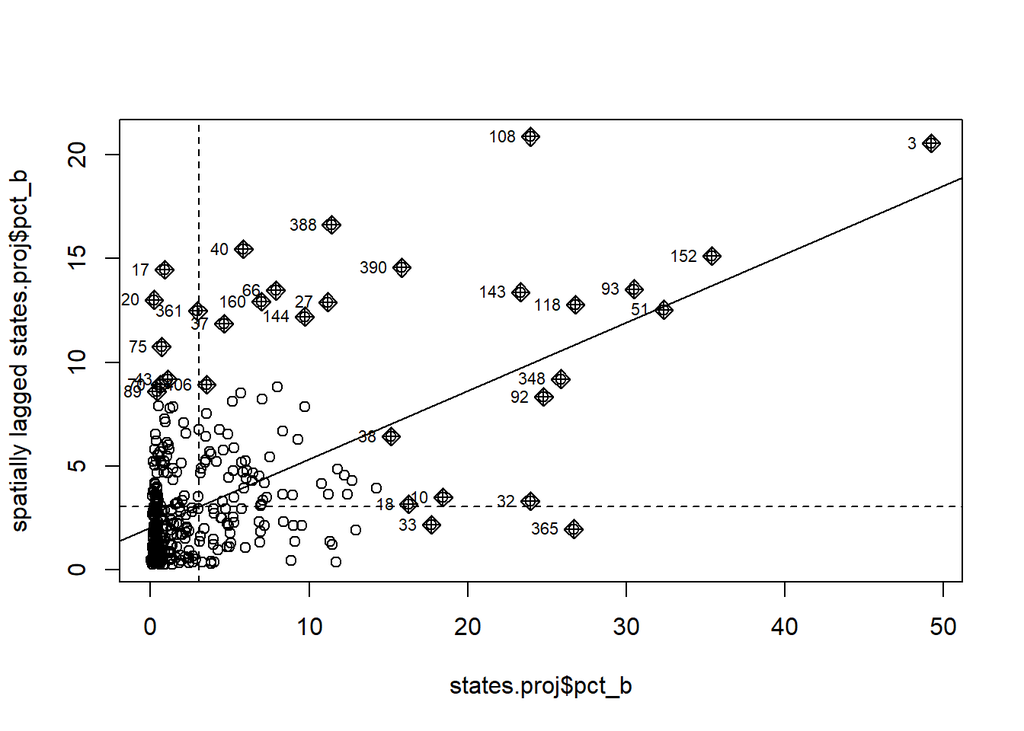

```r
moran.plot(states.proj$pct_b, states.w, zero.policy=TRUE, plot=TRUE)
```

6. Repeat #5 (and 5.a - 5.d) above with a W developed using the IDW method. You will need to investigate the spdep documentation to find the correct method/function.

```r
pts <- st_centroid(states.proj)
idw_world <- dnearneigh(pts, 0, 50000)
states.idw <- nb2listwdist(idw_world, pts, type="idw", style="W", alpha = 0, dmax = NULL, longlat = NULL, zero.policy=T)
idw_world[[1]]
```

```
## [1]   3  20  28 143 300 380
```

```r
pts$NAMELSAD10[1]
```

```
## [1] "Jefferson County"
```

```r
idw_world[[1]] %>% pts$NAMELSAD10[.]
```

```
## [1] "St. Louis city"        "Monroe County"         "Franklin County"
## [4] "St. Louis County"      "Ste. Genevieve County" "Washington County"
```

```r
states.idw$weights[1]
```

```
## [[1]]
## [1] 0.1666667 0.1666667 0.1666667 0.1666667 0.1666667 0.1666667
```